# Adult fish passage in the Willamette River, Oregon

Anna Talken, Alex Ehrens, & Annika Leiby

2/2/2021

## Overview

#### Willamette Falls

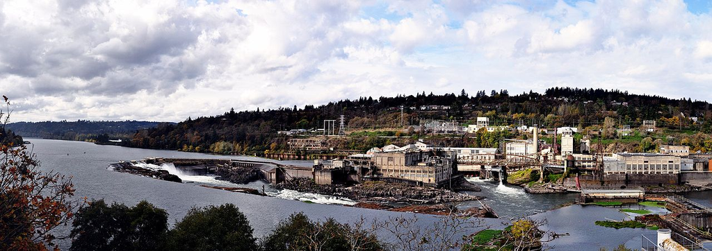

Panorama of the Willamette Falls. Photo credit: Jeff Green

##### Using data from the Columbia Basin Research DART on fish passages at the Willamette Falls fish ladder in Oregon, this report presents a time series analysis to identify changes and patterns in fish observations from January 2001 to December 2010. The first time series analysis captures salmon passage observations over the ten year-period for Coho, Jack Coho and Steelhead salmon. Seasonplots are then used to illustrate the annual seasonal peaks in observed fish within each of the three species from 2001 to 2010. Finally, summary statistics illustrate observed trends in the number of observed fish for each of the three salmon species.

**Citation:** Data Courtesy of [U.S. Army Corps of Engineers, NWD](http://www.nwd.usace.army.mil/) and [Chelan](http://www.chelanpud.org/), [Douglas](http://www.douglaspud.org/), and [Grant](http://www.gcpud.org/) County PUDs, [Yakima Klickitat Fisheries Project](http://www.ykfp.org/), [Colville Tribes Fish & Wildlife (OBMEP)](http://nrd.colvilletribes.com/obmep/), [Oregon Department of Fish & Wildlife](http://www.dfw.state.or.us/), [Washington Department of Fish & Wildlife](http://www.wdfw.wa.gov/).

```r
fish <- read_csv(here("data", "willamette_fish_passage.csv")) %>% clean_names()

fish_ts <- fish %>%
  mutate(date = lubridate::mdy(date)) %>%
  as_tsibble(key = NULL, index = date)
```

## Time Series Summary

### Time series

```r
### select only steelhead, coho, and jack coho species of salmon
fish_ts_original <- fish_ts %>%
  select(project, date, steelhead, coho, jack_coho)

# change all NA values to 0
fish_ts_original[is.na(fish_ts_original)] = 0

# to make facet-wrapped plot, need to pivot this table into a longer format
fish_ts_long <- fish_ts_original %>%
  pivot_longer(cols = steelhead:jack_coho,
               names_to = "species",
               values_to = "count") %>%
  mutate(species = case_when(
    species == "coho" ~ "Coho",
    species == "jack_coho" ~ "Jack Coho",
    species == "steelhead" ~ "Steelhead"
  ))
```

#### Original time series plots

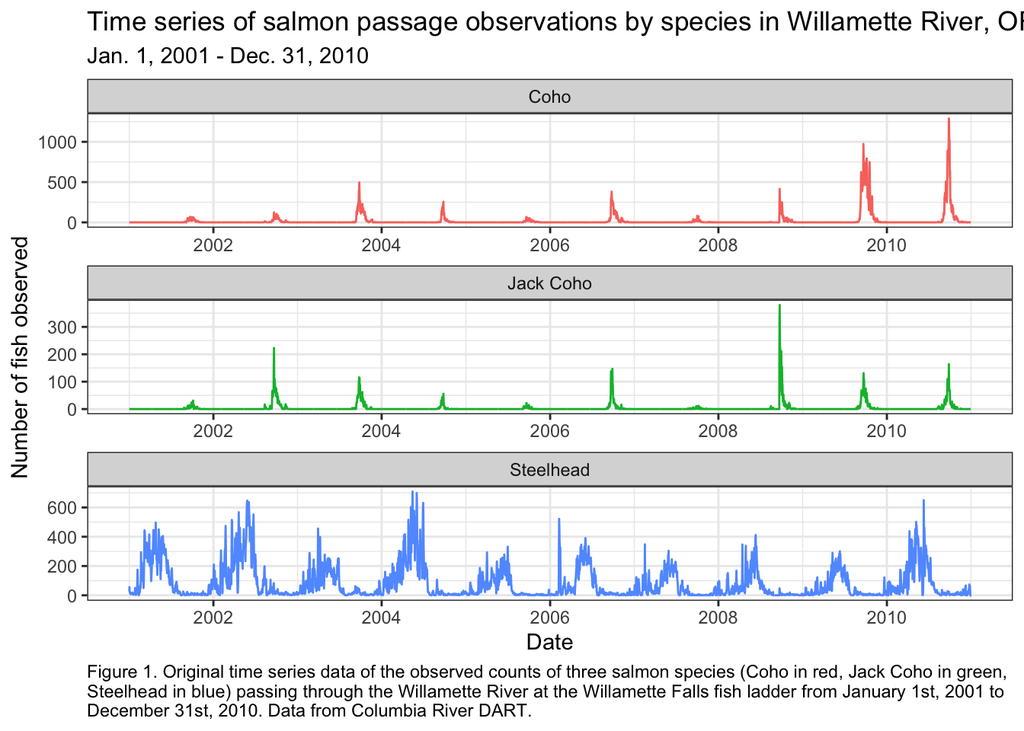

```r
ggplot(data = fish_ts_long, aes(x = date, y = count, color = species)) +
  geom_line(show.legend = FALSE) +
  facet_wrap(~species, dir = "v", scales = "free") +
  theme_bw() +
  labs(title = "Time series of salmon passage observations by species in Willamette River, OR",
       subtitle = "Jan. 1, 2001 - Dec. 31, 2010",
       x = "Date",
       y = "Number of fish observed",
       caption = "Figure 1. Original time series data of the observed counts of three salmon species (Coho in red, Jack Coho in green, \nSteelhead in blue) passing through the Willamette River at the Willamette Falls fish ladder from January 1st, 2001 to \nDecember 31st, 2010. Data from Columbia River DART.")+
  theme(plot.caption = element_text(hjust = 0))
```

#### Notable Trends and Patterns

- All fish species counts seem to display some seasonality as to when peak observations occur, as spikes in fish passage are seen at roughly the same time of the calendar year for each species. Coho and Jack Coho salmon counts spike at roughly the same time of year as each other, and peak Steelhead season occurs a bit earlier in the calendar year. The ‘Seasonplots’ tab will investigate these patterns in more detail.
- Jack Coho are observed the least out of the three species (max. ~400). For most of the time series, Steelhead was the most observed fish (max. ~700), but in the most recent two years (2009 & 2010), Coho observations reached the highest peaks of any species (max. ~1300).
- From these time series plots, it is difficult to discern any overall annual trends in fish passage, with the exception of the rapid increase in peak Coho observations from 2007 to 2010. The ‘Summary statistics and analysis’ tab will investigate annual trends further.

### Seasonplots

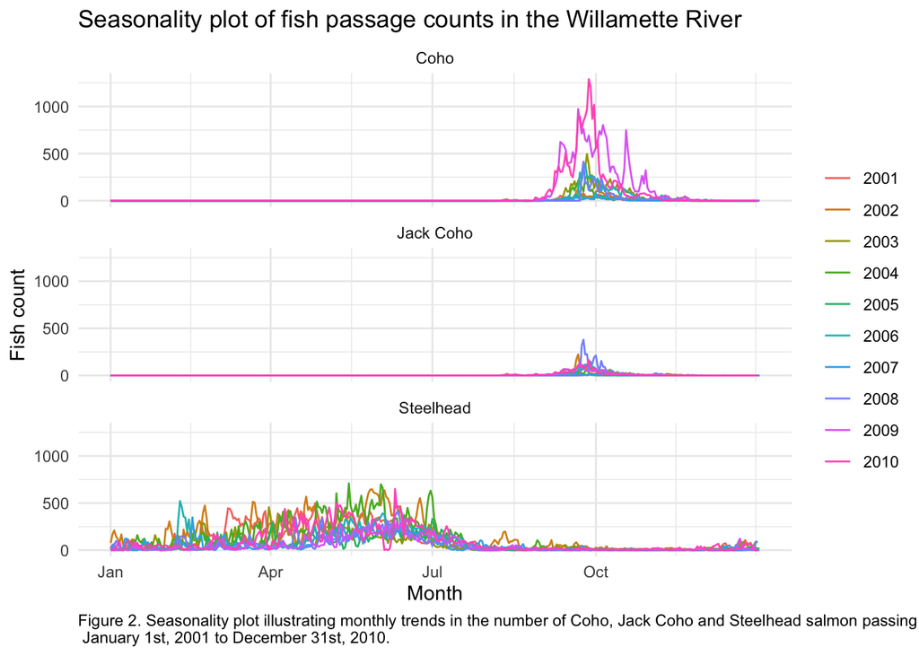

```r
#Wrangle data to group the average fish count by month and year, for each species

fish_ts_long %>%
  gg_season(y = count) +
  facet_wrap(~species, ncol = 1) +
  theme_minimal() +
  labs(title = "Seasonality plot of fish passage counts in the Willamette River",
       x = "Month",
       y = "Fish count",
       caption = "Figure 2. Seasonality plot illustrating monthly trends in the number of Coho, Jack Coho and Steelhead salmon passing through the Willamette River \n January 1st, 2001 to December 31st, 2010.") +
  theme(plot.caption = element_text(hjust = 0))
```

### Summary statistics and analysis

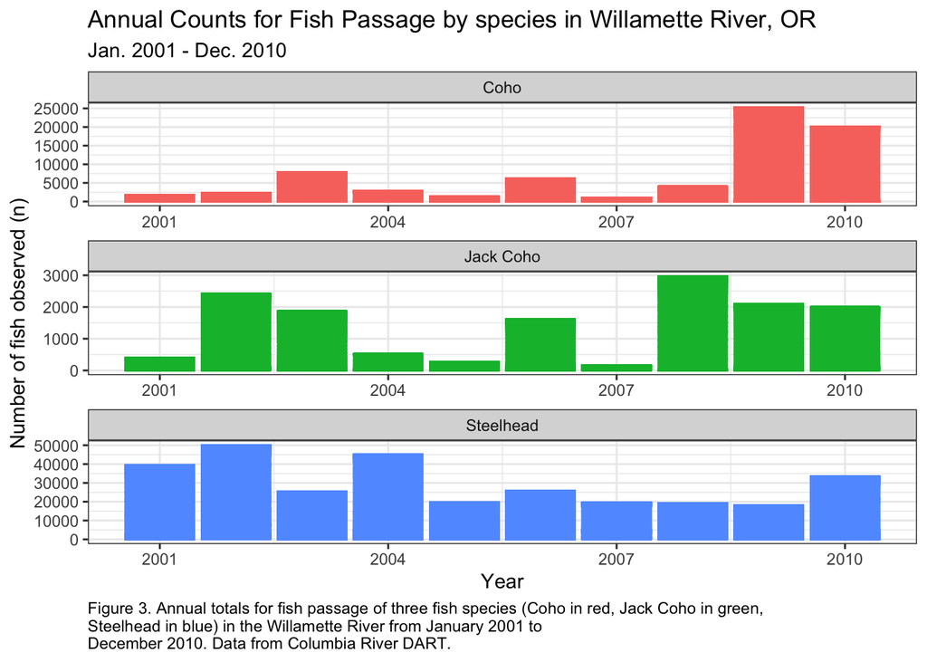

```r
# Make annual counts by species

fish_annual_counts <- fish_ts_long %>%
  mutate(year = as.integer(year(date))) %>%
    group_by(year, species) %>%
  summarize(n = sum(count))

# Make plot that displays this information

fish_annual_counts_plot <- ggplot(data = fish_annual_counts, aes(x = year, y = n)) +
  geom_col(aes(color = species, fill = species), show.legend = FALSE) +
  theme_bw() +
  facet_wrap(~species, dir = "v", scales = "free") +
  scale_x_continuous(breaks = c(2001, 2004, 2007, 2010)) +
  labs(title = "Annual Counts for Fish Passage by species in Willamette River, OR",
       subtitle = "Jan. 2001 - Dec. 2010",
       x = "Year",
       y = "Number of fish observed (n)",
       caption = "Figure 3. Annual totals for fish passage of three fish species (Coho in red, Jack Coho in green, \nSteelhead in blue) in the Willamette River from January 2001 to \nDecember 2010. Data from Columbia River DART.") +
  theme(plot.caption = element_text(hjust = 0))


fish_annual_counts_plot
```

- Both Coho and Jack Coho species experienced the lowest number of observed counts in the year 2007. Coho count for the year 2007 was 1050 and Jack Coho count in 2007 was only 164. Steelhead experienced its third lowest count during the year 2007, which indicates 2007 was not a good year for fish count observations across the board.
- Steelhead species typically have much higher counts as compared to Coho and Jack Coho species with a range of observations from 0-50,000. The range of Coho observations is 0-25,000 and the range of Jack Coho is even smaller from 0-3,000.